# Housing Cri.. Prices

## 2.3 Model Selection

Here, model selection can be directly done with the expected prediction error of the learning procedure. This will be done using cross validation. The root-mean-squared-error (RMSE) of the log of the target variable is defined as error.

```r
L <- function(Y, Yh) sqrt(sum((Y - Yh)^2) / length(Y))
```

Inside the cross validation a prediction function will train a MARS model on one part of the training set and then predict the other. The RMSE for the prediction will be returned.

```r
predMARS <- function(trainX, trainY, testX, testY, ...) {
  fit <- earth(trainX, trainY, nk = 200, ...)
  pred <- predict(fit, newdata = testX)
  return(L(testY, pred[, 1]))
}
```

Splitting of the data and execution of the prediction function is performed by `crossval`. For each model it will repeat a 5-fold cross validation 10 times. The resulting mean RMSE and its standard error are stored in a list.

```r
CV <- list()
CV$Add <- crossval(predMARS, X, Y,
                   verbose = FALSE, K = 5, B = 10)
CV$Add_imp <- crossval(predMARS, Ximp, Y,
                       verbose = FALSE, K = 5, B = 10)
CV$Add_small <- crossval(predMARS, Xsmall, Y,
                         verbose = FALSE, K = 5, B = 10)
# CV$Int <- crossval(predMARS, X, Y, degree = 2,
#                    verbose = FALSE, K = 5, B = 10)
# CV$Int_imp <- crossval(predMARS, Ximp, Y, degree = 2,
#                        verbose = FALSE, K = 5, B = 10)
# CV$Int_small <- crossval(predMARS, Xsmall, Y, degree = 2,
#                          verbose = FALSE, K = 5, B = 10)
```

Cases with interaction terms take to long to compute on kaggle, so they are commented out. Overall they performed worse than their additive counterparts. Estimated RMSEs for all models are shown below.

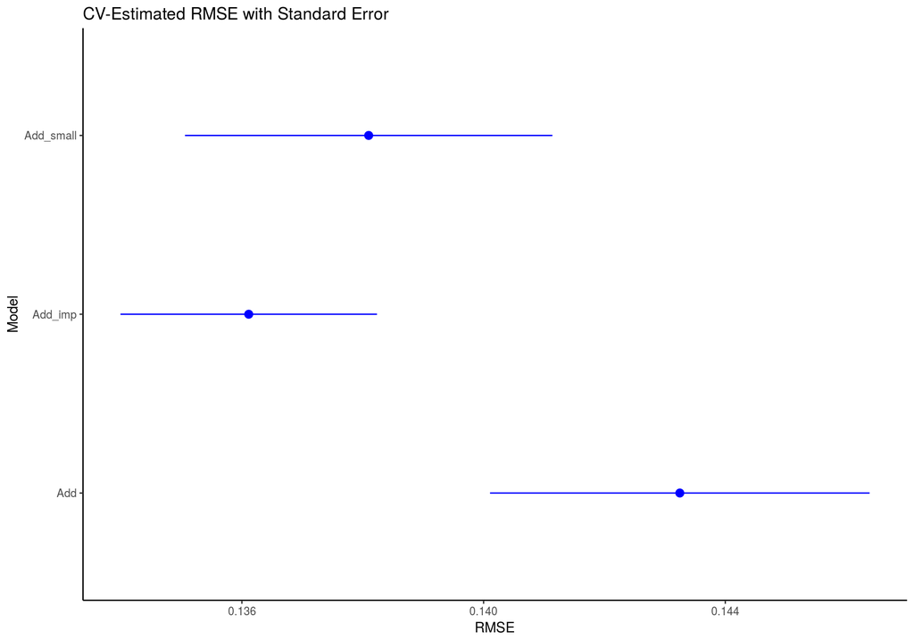

```r
l <- lapply(CV, function(i) data.frame(RMSE = i$stat, se = i$stat.se))
res <- do.call(rbind, l)
res$Model <- rownames(res)
ggplot(res, aes(x = Model, y = RMSE)) +
  geom_pointrange(aes(ymax = RMSE + se, ymin = RMSE - se), color = "blue") +
  coord_flip() +
  ggtitle("CV-Estimated RMSE with Standard Error") +
  theme_classic()
```

## 2.4 Final Model

*Add_imp* will be trained as final model.

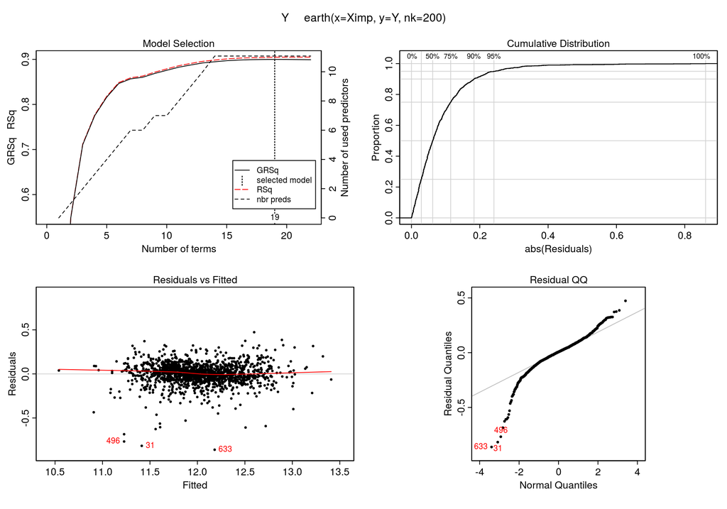

```r
fit <- earth(Ximp, Y, nk = 200)
plot(fit)
```

```r
summary(fit, decomp = "none")
```

```
## Call: earth(x=Ximp, y=Y, nk=200)
##
##                        coefficients
## (Intercept)              12.1873398
## h(OverallQual-5)         -0.0454597
## h(5-OverallQual)          0.1052504
## h(GrLivArea-3.47407)     -4.6186116
## h(3.47407-GrLivArea)     -1.0320685
## h(BsmtFinSF1-2.58883)     0.1295440
## h(2.58883-BsmtFinSF1)    -0.0222658
## h(YearBuilt-2004)         0.0255815
## h(2004-YearBuilt)        -0.0034433
## h(OverallCond-4)         -0.0671320
## h(4-OverallCond)          0.0304517
## h(LotArea-3.50284)        0.1969462
## h(3.50284-LotArea)       -0.2787826
## h(X2ndFlrSF-3.1345)       5.7840397
## h(GarageCars-1)           0.0493461
## h(1-GarageCars)          -0.0611909
## h(TotalBsmtSF-2.68485)    0.3024267
## NeighborhoodCrawfor       0.1531861
## h(2-KitchenAbvGr)         0.1080447
##
## Selected 19 of 22 terms, and 11 of 119 predictors
## Termination condition: RSq changed by less than 0.001 at 22 terms
## Importance: OverallQual, YearBuilt, GrLivArea, OverallCond, ...
## Number of terms at each degree of interaction: 1 18 (additive model)
## GCV 0.01598557    RSS 22.17098    GRSq 0.8998844    RSq 0.9047641
```

The summary shows the terms in the order they were added during the forward pass. 2 hinge functions for *OverallQual* and *GrLivArea* were added first. These were also the most important features identified by the Boruta analysis.

Another way to estimate the variable importance is by looking at the number of terms in which they were used. This is shown below in the column *nsubsets*. The order of variables changed here compared to the summary.

```r
evimp(fit)[1:10, ]
```

```
##                     col used nsubsets       gcv gcv.match       rss
## OverallQual          43    1       17 100.00000         1 100.00000
## YearBuilt            45    1       17  69.07005         1  69.21421
## GrLivArea            94    1       17  69.07005         1  69.21421
## OverallCond          44    1       15  41.13027         1  41.50020
## TotalBsmtSF          89    1       14  33.70724         1  34.17469
## LotArea               7    1       13  26.92642         1  27.53371
## X2ndFlrSF            93    1       11  23.17427         1  23.73980
## BsmtFinSF1           87    1        9  18.09552         1  18.71241
## NeighborhoodCrawfor  16    1        8  15.32108         1  15.99952
## GarageCars          112    1        7  12.95308         1  13.68045
##                     rss.match
## OverallQual                 1
## YearBuilt                   1
## GrLivArea                   1
## OverallCond                 1
## TotalBsmtSF                 1
## LotArea                     1
## X2ndFlrSF                   1
## BsmtFinSF1                  1
## NeighborhoodCrawfor         1
## GarageCars                  1
```

# 3 Prediction

Finally the test set can be predicted.

```r
Xtest <- test[, impVars, with = FALSE]
pred <- predict(fit, newdata = Xtest)[, 1]
```

The actual prices are shown below.

```r
prices <- exp(pred)
summary(prices)
```

```
##    Min. 1st Qu.  Median    Mean 3rd Qu.    Max.
##   48430  127500  158400  178700  211200  728700
```

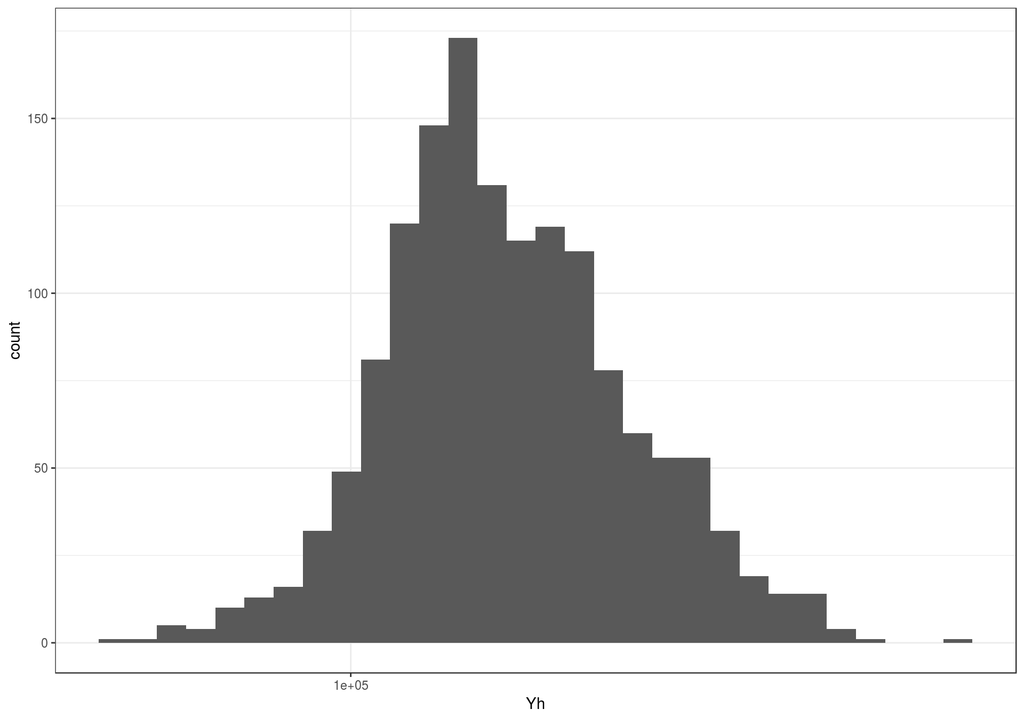

```r
ggplot(data.frame(Yh = prices), aes(x = Yh)) +
  geom_histogram(bins = 30) +
  scale_x_continuous(trans = "log10") +
  theme_bw()
```

That’s it! Thanks for reading through this whole thing. If you have any suggestions, comments are welcome.

```r
df <- data.frame(
  Id = test$Id,
  SalePrice = prices
)
write.csv(df, file = "MARS_submission.csv", row.names = FALSE, quote = FALSE)
```